# From monomers to mechanisms: an end-to-end ABC workflow

## The question, and the workflow

Large tandem repeat arrays — centromeric satellites, knobs, subtelomeric repeats — are built by mechanisms nobody can watch directly: tandem duplication of multi-monomer units, longer-range duplication within a chromosome, and exchange of blocks between chromosomes. What we *can* observe is the end product: thousands to millions of monomers whose sequences and positions carry a fossil record of those events.

reCYCLing turns that record into inference by simulation. The workflow has four steps, and this vignette runs all of them end to end at toy scale:

1. **Observe** — extract per-monomer sequences from real assemblies (e.g. with TRASH) and import them (`assemble_genome_dt()`).
2. **Describe** — reduce a genome of monomers to a fixed-length vector of summary statistics (`repeat_genome_stats()`, `repeat_abc_predictors()`). The *same* functions score real and simulated genomes, so the two are comparable by construction.
3. **Simulate** — draw mechanism parameters from priors, evolve simulated genomes (`sim_genome()`), and score them, building a reference table.
4. **Infer** — use random-forest ABC (the `abcrf` package) for model choice (“is mechanism X present at all?”) and parameter posteriors, then check the fit by simulating at the posterior estimates (posterior-predictive check).

Everything below runs in a couple of minutes on a laptop. The final section shows how the same code scales to real inference (tens of thousands of simulations on a cluster).

## Step 0 — the generative model

`sim_genome()` evolves a multi-chromosome genome of monomers forward in time. Each chromosome starts as a small array of identical copies of one ancestral monomer and grows toward a target size under:

| Mechanism | Rate parameter | Size parameter |
| --- | --- | --- |
| Local (tandem) duplication of a multi-monomer unit | `p_local_dup` (per monomer per generation) | `local_dist` |
| Long-range duplication within a chromosome | `p_distal_dup` (per chromosome per generation) | `distal_dist` |
| Inter-chromosomal exchange (copy a block to another chromosome) | `p_translocation` (per genome per generation) | `transloc_chunk_mean` |
| Point mutation (the molecular clock) | `mu_total` (per base per generation) | — |

A size governor (deletion) keeps each chromosome near its target once reached, so arrays keep *turning over* rather than growing without bound — the regime real satellite arrays live in.

The output is the package’s central **data contract**: a `data.table` with one row per monomer and columns `chrom` (integer 1..K), `num` (position within the chromosome), `bponly` (gapless sequence), and `dir` (strand).

```r
g <- sim_genome(
  K             = 3,
  target_sizes  = c(600, 450, 300),
  n_generations = 250,
  mu_total      = 5e-5,
  p_local_dup   = 2.5e-4,
  local_dist    = list(type = "gamma", shape = 2, scale = 8 / 2),
  p_distal_dup  = 0.05,
  distal_dist   = list(type = "gamma", shape = 2, scale = 300 / 2),
  p_translocation     = 0.2,
  transloc_chunk_mean = 100
)
head(g, 3)
```

```
#>    chrom   num
#>    <int> <int>
#> 1:     1     1
#> 2:     1     2
#> 3:     1     3
#>                                                                                                                                                                                bponly
#>                                                                                                                                                                                <char>
#> 1: ACGCCCCTTTTACAGCGCTCGCTCACGTCATTAATGTGGCTGTGCTTGGCATAACTTACGGCCGTCAGCTTGTTTTGGGTCTCAGCAGTGATTGGATCGTCGAATAAATGTGCCTGGGAAGGACCACCGTTGAGCCCTTCCTACTGGAGATAGTGAAAGGTCTAAACACCTCTTGTGC
#> 2: ACGCCCCTTTTACCGCGCTCGCTCACGTCATTAATGTGGCTGTGCTTGGCATAACTTACGGCCGTCAGCTTGTTTTGGGTCTTAGCAGTGATTAGATCGTCGAATAAATGTGCCTGGGAAGGACCACTGTTGAGCCCTTCCTACTGGAGATAGTGAAAGGTCTAAACACCTCTTGTAC
#> 3: ACGCCCCTTTTACAGCGCTCGCTCACGTCATTAATGTGGCTGTGCTTGGCATAACTTACGGCCGTCAGCTTGTTTTGGGTCTCAGCAGTGATTGGATCGTCGAATAAATGTGCCTGGGAAGGACCACCTTTGAGCCCTTCCTACTGGAGATAGTGAAAGGTCTAAACACCTCTTGTGC
#>       dir
#>    <char>
#> 1:      +
#> 2:      -
#> 3:      -
```

```r
table(g$chrom)
```

```
#>
#>   1   2   3
#> 328 513 253
```

## Step 1 — observed data

### Real assemblies

For real genomes, run a monomer annotator such as TRASH on each chromosome-scale assembly to get one fasta of monomers per chromosome (optionally aligned, i.e. gapped). `assemble_genome_dt()` parses the fasta headers — split on `sep`, with the chromosome id, monomer position, and strand at fixed field positions — and returns the data contract above:

```r
files <- list.files("monomers/", pattern = "\\.fasta$", full.names = TRUE)
obs <- assemble_genome_dt(files,
                          chrom_field = 3,   # e.g. "sp_hap1_Chr01_00042_..._+"
                          num_field   = 4,
                          dir_field   = 7,
                          sep         = "_")
```

For a single array (one chromosome) there is a one-call shortcut, `repeat_stats_from_fasta()`, which goes straight from fasta to the stat object of Step 2.

### A round trip you can run

To show the import path without shipping data, we write one simulated chromosome out as a TRASH-style monomer fasta and read it back:

```r
fa <- tempfile(fileext = ".fasta")
sub <- g[chrom == 1L]
writeLines(paste0(">mono_demo_Chr01_", sub$num, "_x_x_", sub$dir, "\n", sub$bponly), fa)
back <- assemble_genome_dt(fa, chrom_field = 3, num_field = 4, dir_field = 7)
identical(back$bponly, sub$bponly)
```

```
#> [1] TRUE
```

### Pseudo-observed genomes with known truth

For the rest of this vignette we use two simulated genomes as “observations”, so we know the truth the inference should recover: one evolved **with** inter-chromosomal exchange, one **without**.

```r
make_obs <- function(p_xch, seed) {
  set.seed(seed)
  sim_genome(K = 3, target_sizes = c(600, 450, 300), n_generations = 250,
             mu_total = 5e-5, p_local_dup = 2.5e-4,
             local_dist  = list(type = "gamma", shape = 2, scale = 8 / 2),
             p_distal_dup = 0.05,
             distal_dist = list(type = "gamma", shape = 2, scale = 300 / 2),
             p_translocation = p_xch, transloc_chunk_mean = 100)
}
obs_with    <- make_obs(p_xch = 0.2, seed = 101)  # exchange PRESENT
obs_without <- make_obs(p_xch = 0,   seed = 102)  # exchange ABSENT
```

## Step 2 — summary statistics

`repeat_genome_stats()` reduces a genome to a stat object; the two flatteners turn it into named numeric vectors:

- `repeat_genome_predictors()` — the **full catalog** (every statistic the package computes, fixed length, NA-safe). Use this for reference tables: storing everything means you can change the fitted subset later without re-simulating, and unfitted statistics become free posterior-predictive checks.
- `repeat_abc_predictors()` — a curated **fit subset** built from three interpretable families, designed for mechanism inference:

[output not shown]

```r
st <- repeat_genome_stats(obs_with)
obs_stats <- rbind(
  with_exchange    = repeat_abc_predictors(st),
  without_exchange = repeat_abc_predictors(repeat_genome_stats(obs_without))
)
length(repeat_genome_predictors(st))   # full catalog
```

```
#> [1] 87
```

```r
ncol(obs_stats)                        # fit subset
```

```
#> [1] 39
```

```r
round(obs_stats[, c("mean_div_bp_m", "frac_pairs_xchrom", "log_array_size_m")], 3)
```

```
#>                  mean_div_bp_m frac_pairs_xchrom log_array_size_m
#> with_exchange            2.197             0.442            2.616
#> without_exchange         2.083             0.000            2.615
```

The two genomes have the same age and size, but the exchange signal (`frac_pairs_xchrom`) separates them already. The inference below formalizes that.

## Step 3 — a reference table

Draw parameters from priors, simulate, score. Two design points worth copying at any scale:

- **Spike and slab.** Each optional mechanism is switched *off* entirely in a fraction of simulations (here 1/3). That turns “is exchange present?” into a model-choice problem a classification forest can answer.
- **Store the full catalog** (`repeat_genome_predictors()`), select the fit subset (`repeat_abc_predictors()`) downstream.

```r
rlunif <- function(n, lo, hi) 10^runif(n, log10(lo), log10(hi))
SPIKE <- 1/3

draw_prior <- function() {
  has_xch <- runif(1) >= SPIKE
  list(n_generations = round(runif(1, 80, 400)),
       local_mean    = rlunif(1, 2, 50),
       p_distal      = rlunif(1, 1e-3, 0.3),
       distal_mean   = rlunif(1, 50, 1000),
       p_xch         = if (has_xch) rlunif(1, 1e-2, 0.9) else 0,
       xch_mean      = if (has_xch) rlunif(1, 10, 500) else NA_real_)
}

simulate_one <- function(pr) {
  sim <- sim_genome(K = 3, target_sizes = round(rlunif(3, 200, 800)),
                    n_generations = pr$n_generations,
                    mu_total = 5e-5, p_local_dup = 2.5e-4,
                    local_dist  = list(type = "gamma", shape = 2, scale = pr$local_mean / 2),
                    p_distal_dup = pr$p_distal,
                    distal_dist = list(type = "gamma", shape = 2, scale = pr$distal_mean / 2),
                    p_translocation     = pr$p_xch,
                    transloc_chunk_mean = if (is.na(pr$xch_mean)) 100 else pr$xch_mean)
  repeat_abc_predictors(repeat_genome_stats(sim))
}

N <- 240
t0 <- Sys.time()
rows <- lapply(seq_len(N), function(i) {
  pr <- draw_prior()
  pred <- tryCatch(simulate_one(pr), error = function(e) NULL)
  if (is.null(pred)) return(NULL)
  c(unlist(pr[c("n_generations", "local_mean", "p_xch")]), pred)
})
ref <- as.data.table(do.call(rbind, Filter(Negate(is.null), rows)))
ref <- ref[complete.cases(ref)]
cat(sprintf("%d usable simulations in %.1f min\n",
            nrow(ref), as.numeric(Sys.time() - t0, units = "mins")))
```

```
#> 210 usable simulations in 0.8 min
```

```r
# statistics that never vary at this toy scale (fixed K, empty divergence
# bins) carry no information here — drop them before training
stat_cols <- setdiff(colnames(ref), c("n_generations", "local_mean", "p_xch"))
stat_cols <- stat_cols[sapply(ref[, ..stat_cols], sd) > 0]
```

## Step 4 — inference with random forests

Random-forest ABC (Pudlo et al. 2016; Raynal et al. 2019, both via the `abcrf` package) uses the reference table as a training set: a classification forest votes on mechanism presence, a regression forest estimates parameter posteriors. Forests tolerate many correlated statistics, so no statistic pre-selection is needed.

### Model choice: is exchange present?

```r
library(abcrf)
train <- data.frame(mod = factor(ifelse(ref$p_xch > 0, "present", "absent")),
                    ref[, ..stat_cols])
obs_df <- data.frame(obs_stats)[, stat_cols]

rf_mc  <- abcrf(mod ~ ., data = train, ntree = 200, paral = FALSE)
votes  <- predict(rf_mc, obs_df, train, ntree = 200, paral = FALSE)
data.frame(genome   = rownames(obs_stats),
           truth    = c("present", "absent"),
           P_present = round(votes$vote[, "present"] / rowSums(votes$vote), 2))
```

```
#>             genome   truth P_present
#> 1    with_exchange present      1.00
#> 2 without_exchange  absent      0.08
```

The forest assigns a high probability of exchange to the genome simulated with it and a low one to the genome without — with only 210 training simulations.

### Parameter posteriors

A regression forest per parameter gives posterior medians and credible intervals. Here: array age (`n_generations`) and the local duplication unit size (`local_mean`), with the known truth alongside.

```r
posterior <- function(param, obs_row) {
  tr <- data.frame(r = ref[[param]], ref[, ..stat_cols])
  rf <- regAbcrf(r ~ ., data = tr, ntree = 200, paral = FALSE)
  pr <- predict(rf, obs_df[obs_row, , drop = FALSE], tr,
                quantiles = c(0.025, 0.5, 0.975), paral = FALSE)
  c(median = pr$med[1], lo = pr$quantiles[1], hi = pr$quantiles[3])
}
res <- rbind(
  age_generations = posterior("n_generations", 1),
  local_mean      = posterior("local_mean", 1)
)
cbind(round(res, 1), truth = c(250, 8))
```

```
#>                 median    lo    hi truth
#> age_generations  241.6 205.0 297.0   250
#> local_mean         5.2   2.3  43.3     8
```

Even this toy table recovers age well (the divergence family is a clock) and puts the local unit size in the right range; at real scale (30k simulations) both tighten substantially, and cross-validation on held-out simulations quantifies exactly how much (see `abcrf::err.regAbcrf` and the scaling section below).

## Step 5 — posterior-predictive check

The loop closes by simulating at the inferred values and asking whether the result resembles the observation — including in statistics that were *never fitted*. Here we overlay the fitted within-chromosome distance histogram (`wxd`).

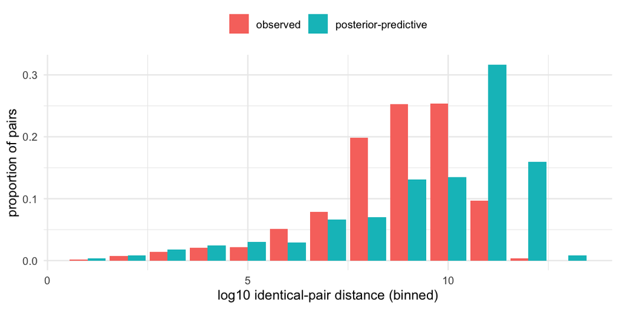

```r
library(ggplot2)
sim_pp <- sim_genome(K = 3, target_sizes = c(600, 450, 300),
                     n_generations = round(res["age_generations", "median"]),
                     mu_total = 5e-5, p_local_dup = 2.5e-4,
                     local_dist  = list(type = "gamma", shape = 2,
                                        scale = res["local_mean", "median"] / 2),
                     p_distal_dup = 0.05,
                     distal_dist = list(type = "gamma", shape = 2, scale = 300 / 2),
                     p_translocation = 0.2, transloc_chunk_mean = 100)
pp <- repeat_abc_predictors(repeat_genome_stats(sim_pp))

wxd <- grep("^wxd", stat_cols, value = TRUE)
dt <- rbind(data.table(bin = seq_along(wxd), p = obs_stats["with_exchange", wxd], who = "observed"),
            data.table(bin = seq_along(wxd), p = pp[wxd], who = "posterior-predictive"))
ggplot(dt, aes(bin, p, fill = who)) +
  geom_col(position = "dodge") +
  labs(x = "log10 identical-pair distance (binned)", y = "proportion of pairs",
       fill = NULL) +
  theme_minimal() + theme(legend.position = "top")
```

A systematic mismatch — especially in held-out statistics — is not a failure of the workflow but its most useful output: it points at a mechanism the model lacks.

## Scaling to real inference

The toy above is the real pipeline in miniature. At publication scale the same calls change only in size and placement:

```r
## Reference table: ~30,000 simulations, full catalog, on a cluster.
## One genome per row; checkpoint batches to .rds so preempted jobs resume.
pred <- repeat_genome_predictors(repeat_genome_stats(sim))   # store EVERYTHING

## Real data: one fit per genome/haplotype.
obs  <- assemble_genome_dt(chromosome_fastas)                # TRASH monomers
v    <- repeat_abc_predictors(repeat_genome_stats(obs))

## Inference: abcrf with ntree = 500-1000, parallel;
## validate with ~1000 held-out simulations as pseudo-observations
## (parameter recovery, CI coverage, false-positive rate of model choice).
```

Practices that matter at scale:

- **Fit per genome, then pool.** With several genomes (haplotypes, accessions, species), fit each independently and compare or pool posteriors — independent haplotypes of the same genotype are a built-in replication check.
- **Hold statistics out.** Fit on the three families above; everything else in the full catalog scores the fit afterwards.
- **Validate the estimator.** Treat held-out simulations as pseudo-observations: parameter recovery, credible-interval coverage, and — for model choice — how often a truly-absent mechanism reaches the vote level of your real genomes.

## Function reference

| Step | Function | Purpose |
| --- | --- | --- |
| Simulate | `sim_genome()` | multi-chromosome genome under the mechanism model |
| Simulate | `run_sim_ps()` | single array, with identical-pair tracking and plots (see the intro vignette) |
| Import | `assemble_genome_dt()` | monomer fastas (TRASH-style headers) → genome data contract |
| Import | `repeat_stats_from_fasta()` | single-array fasta → stat object, one call |
| Describe | `repeat_genome_stats()` | genome → stat object |
| Describe | `repeat_genome_predictors()` | stat object → full catalog vector |
| Describe | `repeat_abc_predictors()` | stat object → curated fit subset |
| Describe | `repeat_summary_stats()`, `repeat_predictors()` | array-level equivalents |
| Visualize | `plot_repeat_fingerprint()`, `plot_repeat_barcode()`, `plot_ps_summary()` | array structure plots |